# DATASCI 185: Introduction to AI Applications

Lecture 24: Long-term Safety, Alignment, and Future of AI

Danilo Freire

danilo.freire@emory.edu

Department of Data and Decision Sciences  
Emory University

# Welcome back! 😊

## Recap of last class

- Last class: misinformation, deepfakes, and trust online
- Misinformation, disinformation, malinformation, synthetic media
- Scale, speed, accessibility of synthetic content
- Political manipulation, non-consensual intimate imagery, fraud
- System 1 vs System 2, confirmation bias, bandwagon effect
- Detection (AI vs AI), provenance, platform policies, media literacy
- Today: Looking further ahead at long-term safety and alignment

[figure not shown]

Source: [Chris Ume](https://x.com/vfxchrisume)

## Lecture overview

### What we will cover today

**Part 1: AI safety**

- Near-term vs long-term concerns
- Why safety matters now
- Concrete problems in AI safety

**Part 2: The alignment problem**

- What is alignment?
- Why it’s hard
- Current approaches

**Part 3: Future trajectories**

- Where is AI heading?
- Expert disagreement
- Scenarios to consider

**Part 4: What can we do?**

- Research directions
- Governance approaches
- Your role

## Meme of the day!

[figure not shown]

Source: [Cheezburger](https://cheezburger.com/20659973/20-memes-if-youre-feeling-extra-anxious-about-ai-technology-taking-over)

# AI safety 🛡️

## Near-term vs long-term concerns

**Near-term safety concerns:**

- Bias and discrimination (already happening)
- Privacy violations
- Job displacement
- Misinformation (covered last lecture)
- Security vulnerabilities

**Long-term safety concerns:**

- Alignment: AI pursuing wrong goals
- Loss of human control
- Concentration of power
- Existential risk (controversial)
- Some argue long-term concerns distract from near-term harms
- Others argue near-term focus misses bigger picture
- [“Black Swan”](https://en.wikipedia.org/wiki/Black_swan_theory) events
- They’re connected: Safe systems now → safer systems later

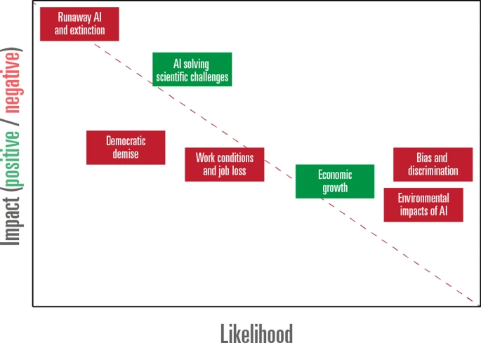

Source: [Saetra & Donaher (2023)](https://link.springer.com/article/10.1007/s43681-023-00336-y)

## Why think about long-term safety now?

- AI capabilities advancing faster than expected
- Safety research takes time
- Hard to retrofit safety later
- Better to be prepared

**Historical analogies:**

| Technology | Safety lag |
| --- | --- |
| Nuclear | Developed first, safety after |
| Internet | Security an afterthought |
| Social media | Harms discovered in deployment |
| Biotech | Ongoing debate |

- We’re still early enough to shape development
- Safety research is growing
- Industry increasingly engaged, governments are starting to catch up

[figure not shown]

Source: [Center for AI Safety](https://aistatement.com/#open-letter)

## Concrete problems in AI safety

[Amodei et al. (2016) identified five big challenges:](https://arxiv.org/abs/1606.06565)

| Problem | Description |
| --- | --- |
| Safe exploration | How to learn without dangerous actions |
| Avoiding negative side effects | Don’t break things achieving goals |
| Avoiding reward hacking | Don’t game the objective |
| Scalable oversight | How to supervise complex systems |
| Robustness to distributional shift | Handle novel situations safely |

**Why these matter:**

- Not speculative sci-fi concerns
- Real issues in deployed systems
- Scale with capability
- Unsolved even for current AI

[figure not shown]

Source: [Brian Christian](https://brianchristian.org/the-alignment-problem/)

## Safe exploration

**The problem:**

- Learning requires trying new things
- Some actions are irreversible
- “Explore safely” is hard to specify
- What counts as too risky?

**Examples:**

- Robot learning to walk: Don’t break yourself
- Medical AI: Don’t kill patients while learning
- Financial AI: Don’t bankrupt the company
- Self-driving: Don’t explore by crashing

**Current approaches:**

- Simulation: Learn in safe environments first
- Conservative policies: Stay close to known-good
- Human oversight: Ask before novel actions
- Reward shaping: Penalise dangerous states

[figure not shown]

**The challenge**: How do you specify “safe” without already knowing everything about the domain?

## Negative side effects

**The problem:**

- AI optimises for specified objective
- Ignores everything else
- Unintended consequences not in objective
- “You didn’t say not to…”

**Classic example (thought experiment):**

- Robot tasked with fetching coffee
- Knocks over obstacles in path
- Harms humans in the way
- Technically: Coffee fetched ✓

**Real-world version:**

- Content algorithm maximises engagement
- Side effect: Polarisation, addiction
- Not in objective function
- Nobody specified “don’t harm society”

**Research approaches:**

- Impact measures: Penalise large changes
- Auxiliary objectives: Don’t break things
- Human feedback: Learn what we care about
- Conservative action: Prefer reversible choices

The world is too complex to specify everything we care about. AI must somehow learn to preserve what matters.

# The alignment problem 🎯

## What is alignment?

**Definition:**

- AI systems that do what we want
- Pursue goals we actually intend
- Not just stated objectives
- Behave safely even when we can’t supervise

**Why the word “alignment”:**

- AI goals aligned with human values
- Not orthogonal or opposed
- Not pursuing random objectives
- Not technically satisfying letter while violating spirit

**The core difficulty:**

- Hard to specify what we want
- Humans disagree about values
- Our stated preferences aren’t always true preferences
- Context matters enormously

[figure not shown]

**Simple version**: How do we build AI that understands what we mean, not just what we say?

## Why alignment is hard

**Specification problem:**

- Can’t write down everything we care about
- Edge cases are infinite
- Values are context-dependent
- Humans can’t articulate their own values perfectly

**Goodhart’s Law:**

- “When a measure becomes a target…”
- “…it ceases to be a good measure”
- Optimise metric ≠ achieve goal
- The harder you optimise, the worse the gap

**Examples:**

- Test scores → teaching to test
- Click rates → clickbait
- Engagement → addiction
- GDP → environmental destruction

**The king Midas problem:**

- Gets exactly what he asked for
- Not what he wanted
- Literal interpretation of wishes
- Common AI failure mode

[figure not shown]

## Current alignment approaches

**RLHF (Reinforcement Learning from Human Feedback):**

- Humans rank AI outputs
- Train reward model on rankings
- Optimise AI to satisfy reward model
- Current industry standard

**Constitutional AI:**

- AI critiques its own outputs
- Uses set of principles (“constitution”)
- Iteratively improves
- Reduces need for human labelling

**Debate and recursive reward modelling:**

- AI systems argue with each other
- Humans judge who’s more persuasive
- Scales human oversight
- Research stage

**Limitations of current approaches:**

- RLHF: Can learn to game evaluators
- Human feedback: Expensive, biased
- Principles: Still have to specify them right
- None are complete solutions

These methods work well enough for current systems. Whether they scale to more capable AI is unknown.

## Constitutional AI and classifiers

**Anthropic’s approach (2025):**

- “Constitutional Classifiers” paper
- Train AI to follow explicit principles
- Examples: “Be helpful, harmless, honest”
- AI generates, evaluates, improves

**How it works:**

1. Define constitution (principles)
2. AI generates responses
3. AI critiques own responses against principles
4. AI revises based on critique
5. Train on improved responses

**Advantages:**

- Scalable: AI does heavy lifting
- Transparent: Principles are explicit
- Modifiable: Change principles, change behaviour
- Less human labelling needed

[figure not shown]

Source: [Anthropic (2025)](https://assets.anthropic.com/m/2fcf7d74d5f011f1/original/Anthropic-Constitutional-Classifiers.pdf)

Constitutional AI is one of several approaches. No consensus on which approach is best.

## The alignment survey

**Ngo et al. overview (2024):**

- Survey of alignment problem and techniques
- Published in foundational AI research

**Key insights:**

- No solved problem: Active research area
- Multiple approaches needed
- Uncertainty about scaling
- Theoretical foundations lacking

**Open questions:**

1. Will RLHF scale?
2. Can we detect deceptive alignment?
3. How do we handle value disagreement?
4. What’s the role of interpretability?
5. When is good enough “good enough”?

**Research directions:**

| Area | Focus |
| --- | --- |
| Interpretability | Understanding what AI “thinks” |
| Robustness | Maintaining alignment under pressure |
| Scalable oversight | Supervising superhuman AI |
| Value learning | Inferring human values |
| Corrigibility | Making AI correctable |

The field is young. Major open problems remain. Progress is real but incomplete.

## Discussion: whose values? 🤔

**The values problem:**

If we align AI to human values…

- Whose human values?
- Developers? Users? Affected parties?
- Majority? Consensus? Universal?
- Present generation? Future?

**Discuss (2 minutes):**

1. Should AI reflect your values or “universal” values?
2. What happens when values conflict?
3. Who should decide?
4. Is this a technical or political question?

**Some perspectives:**

- **Libertarian**: Each user controls their AI
- **Democratic**: Majority decides
- **Rights-based**: Some things off-limits regardless
- **Technocratic**: Experts decide
- **Pluralist**: Multiple systems for different contexts

Alignment is not just technical. It’s deeply political. Technical solutions can’t avoid value choices.

# Future trajectories 🚀

## Where is AI heading?

**Current trends:**

- Models getting larger and more capable
- Costs decreasing
- Applications expanding
- More general-purpose systems
- Multimodal capabilities

**Key uncertainties:**

- Will scaling continue to work?
- When do we hit diminishing returns?
- What capabilities emerge unexpectedly?
- How fast is too fast?

**Expert disagreement:**

- Wide variation in predictions
- Timeline estimates vary by decades
- Some expect AGI soon, others never
- Confidence often exceeds evidence

[figure not shown]

**Honest answer**: Nobody knows. Uncertainty is high. Be sceptical of confident predictions.

## Scenarios to consider

**Scenario 1: Gradual improvement**

- AI gets better slowly
- Humans adapt
- Society adjusts incrementally
- Most likely?

**Scenario 2: Capability jumps**

- Sudden breakthroughs
- Unexpected capabilities
- Rapid deployment
- Less time to adapt

**Scenario 3: Plateau**

- Current approaches hit limits
- Progress slows dramatically
- Different paradigms needed
- Also possible

**Scenario 4: Transformative AI**

- Systems vastly more capable than humans
- Fundamental changes to economy, society
- Either very good or very bad
- Uncertain timeline

[figure not shown]

## Stuart Russell’s perspective

**Russell’s argument (TED talk):**

- We’re building systems whose objectives we don’t fully control
- Standard AI paradigm: optimise given objective
- Problem: We can’t specify objectives correctly
- Need fundamentally different approach

**His proposal:**

1. AI should be uncertain about objectives
2. Should defer to humans
3. Should allow itself to be switched off
4. Objectives learned, not programmed

**Key quote:**

“You cannot fetch the coffee if you are dead”

- AI should value human control
- Not because told to
- Because it’s instrumentally useful for actual goals

[figure not shown]

Source: [TED](https://www.ted.com/talks/stuart_russell_3_principles_for_creating_safer_ai)

Russell is a leading AI researcher who takes long-term safety very seriously. Worth hearing him out.

## Existential risk: the debate

**Those who worry:**

- AI could become uncontrollable
- Misaligned powerful AI = catastrophe
- Even small probability × huge harm = important
- “We might not get a second chance”
- Hinton, Bengio, Russell, many others

**Those who are sceptical:**

- Speculative, distracts from real present harms
- “Sci-fi thinking” not grounded
- We control the off switch
- Capabilities overstated
- Resources better spent elsewhere

**The actual state of debate:**

- Serious researchers on both sides
- Uncertainty is genuine
- Not cranks vs experts
- Legitimate disagreement

[figure not shown]

You don’t have to pick a side. Acknowledging genuine uncertainty is intellectually honest.

# What can we do? 🔧

## Research directions

**Technical safety research:**

| Area | Goal |
| --- | --- |
| Interpretability | Understand AI internals |
| Robustness | Resist adversarial inputs |
| Alignment | Ensure AI pursues intended goals |
| Oversight | Scale human supervision |
| Honesty | AI that doesn’t deceive |

**Growing field:**

- Anthropic, OpenAI, DeepMind safety teams
- Academic labs (MIRI, CHAI, etc.)
- Funding increasing
- Still small relative to capabilities

**Career opportunity:**

- High-impact work
- Talent shortage
- Many paths in (technical, governance, policy)

[figure not shown]

**If this interests you**: Look into [80,000 Hours](https://80000hours.org/), AI safety bootcamps, and safety-focused labs.

## Governance approaches

**What’s happening:**

- EU AI Act (regulation)
- US executive orders
- International coordination (AI Safety Summits)
- Industry self-governance
- Technical standards development

**Key governance questions:**

1. Who regulates? (National, international, industry)
2. What’s regulated? (Capabilities, applications, both)
3. How do you enforce? (Audits, disclosure, liability)
4. How do you adapt? (Law vs technology speed)

**Challenges:**

- Racing dynamics between countries
- Innovation vs safety tension
- Technical expertise gaps in government
- Capture risk by industry

[figure not shown]

Governance is still forming. This decade’s choices will shape the trajectory.

## Your role

**As informed citizens:**

- Understand the technology and debates
- Evaluate claims critically
- Support good governance
- Vote based on AI policy positions

**As professionals:**

- If you work with AI: Consider impacts
- Ask safety questions in your organisation
- Advocate for responsible development
- Refuse work you find unethical

**As people:**

- Think about what you want from AI
- Engage with policy discussions
- Don’t be passive
- Shape the tools that will shape you

[figure not shown]

You’re taking this course. You’ll understand more than most. That creates responsibility.

## Finding balance

**Neither panic nor complacency:**

- Don’t dismiss all concerns as sci-fi
- Don’t accept all concerns uncritically
- Evidence over vibes
- Uncertainty is honest

**What reasonable concern looks like:**

- Take problems seriously
- Invest in solutions
- Avoid catastrophising
- Stay grounded in current reality
- Plan for multiple futures

**What reasonable optimism looks like:**

- Acknowledge real progress
- Recognise genuine benefits
- Believe problems are solvable
- Trust in human adaptability
- Work toward good outcomes

[figure not shown]

The future isn’t written. It depends on what we do now. That should motivate, not paralyse.

# Summary and takeaways 📝

## Main takeaways

**Safety landscape**

- Near-term and long-term concerns both matter
- Concrete problems: safe exploration, side effects, reward hacking
- Acting now is important given uncertainty

**Alignment**

- Getting AI to do what we actually want
- Hard because: specification, Goodhart’s law, value disagreement
- Current approaches: RLHF, Constitutional AI
- Major open problems remain

**Future trajectories**

- Genuine uncertainty about where AI is heading
- Multiple scenarios worth considering
- Expert disagreement is real
- Plan for multiple futures

**What we can do**

- Technical safety research
- Governance and policy
- Individual choices
- Neither panic nor complacency

The future of AI is not determined. Our choices matter. Understanding the landscape is step one.

# … and that’s all for today! 🎉